# Overview of Basic Data Analysis with R

08/06/2021

## Recap

- Invocation and the Read-Eval-Print Loop
- Constants
- Parsing of R code
- Strings and names
- Functions and operators
- Comments
- Working directory
- Workspace
- Search path
- Documentation

## 3rd-Party Libraries (Packages)

- Compilation of functions and/or data
- Made to ease specific (repetitive) tasks
- Some are general-purpose, others domain-specific
- Currently, 17678 packages on CRAN
- Other locations - Bioconductor, GitHub
- See [CRAN Task Views](https://cran.r-project.org/views)

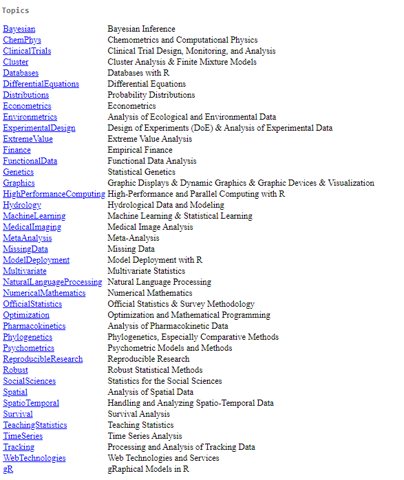

A hypothetical package called **pkg** has a function, `pause()`:

- To install from CRAN - `install.packages("pkg")`
- To learn about the package - `help(package = "pkg")`
- To use `pkg` in R session - `library(pkg)` (or `require`)
- Function `pause()` can be used one-off - `pkg::pause()`
- To detach `pkg` from search path - `detach("package:pkg")`
- To uninstall `pkg` use `remove.packages("pkg")`

## Importing Data

- Note: There are inbuilt datasets
- Import from MS Excel using the *readxl* package
- This object is called a data frame
- Has observations (rows) and variables (columns)

```r
dat <- readxl::read_excel("whostat2005_coverage.xls")

# Alternatively:
# library(readxl)
# dat <- read_excel("whostat2005_coverage.xls")
```

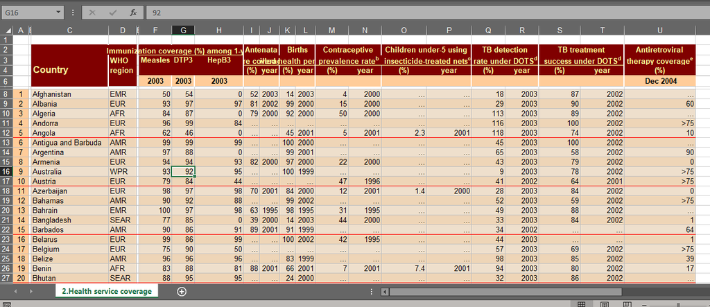

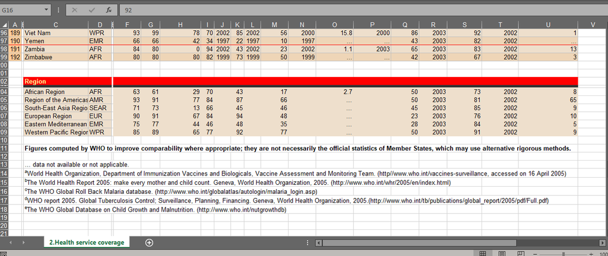

## Data exploration

- `View()` (to find out about it - `?View`)

[figure not shown]

## Data exploration

- `dim()`
- `head()` or `tail()`
- `colnames()`
- `str()`

```r
dim(dat)
```

```
## [1] 216  21
```

```r
head(dat)
```

```
##   ...1 ...2        ...3   ...4 ...5
## 1   NA   NA        <NA>    WHO   NA
## 2   NA   NA     Country region   NA
## 3   NA   NA        <NA>   <NA>   NA
## 4   NA   NA        <NA>   <NA>   NA
## 5   NA   NA        <NA>   <NA>   NA
## 6    1   NA Afghanistan    EMR   NA
##   Immunization coverage (%) among 1-year-oldsa ...7  ...8      Antenatal ...10
## 1                                      Measles DTP3 HepB3 care coverageb  <NA>
## 2                                         <NA> <NA>  <NA>            (%)  year
## 3                                         <NA> <NA>  <NA>           <NA>  <NA>
## 4                                         2003 2003  2003           <NA>  <NA>
## 5                                         <NA> <NA>  <NA>           <NA>  <NA>
## 6                                           50   54     0             52  2003
##          Births attended by ...12    Contraceptive ...14
```

[output cut: 20 more lines]

```r
tail(dat)
```

```
##     ...1 ...2
## 211   NA   NA
## 212   NA   NA
## 213   NA   NA
## 214   NA   NA
## 215   NA   NA
## 216   NA   NA
##                                                                                                                                                                                               ...3
## 211                                                                                                                                                        … data not available or not applicable.
## 212  aWorld Health Organization, Department of Immunization Vaccines and Biologicals, Vaccine Assessment and Monitoring Team. (http//www.who.int/vaccines-surveillance, accessed on 16 April 2005)
## 213                                         bThe World Health Report 2005: make every mother and child count. Geneva, World Health Organization, 2005. (http://www.who.int/whr/2005/en/index.html)
## 214                                                                                       cThe WHO Global Roll Back Malaria database. (http://www.who.int/globalatlas/autologin/malaria_login.asp)
## 215 dWHO report 2005. Global Tuberculosis Control; Surveillance, Planning, Financing. Geneva, World Health Organization, 2005.(http://www.who.int/tb/publications/global_report/2005/pdf/Full.pdf)
## 216                                                                                                  eThe WHO Global Database on Child Growth and Malnutrition. (http://www.who.int/nutgrowthdb)\n
##     ...4 ...5 Immunization coverage (%) among 1-year-oldsa ...7 ...8 Antenatal
```

[output cut: 20 more lines]

```r
colnames(dat)
```

```
##  [1] "...1"
##  [2] "...2"
##  [3] "...3"
##  [4] "...4"
##  [5] "...5"
##  [6] "Immunization coverage (%) among 1-year-oldsa"
##  [7] "...7"
##  [8] "...8"
##  [9] "Antenatal"
## [10] "...10"
## [11] "Births attended by"
## [12] "...12"
## [13] "Contraceptive"
## [14] "...14"
## [15] "Children under-5 using"
## [16] "...16"
## [17] "TB detection"
## [18] "...18"
## [19] "TB treatment"
## [20] "...20"
## [21] "Antiretroviral"
```

```r
str(dat)
```

```
## 'data.frame':    216 obs. of  21 variables:
##  $ ...1                                        : num  NA NA NA NA NA 1 2 3 4 5 ...
##  $ ...2                                        : logi  NA NA NA NA NA NA ...
##  $ ...3                                        : chr  NA "Country" NA NA ...
##  $ ...4                                        : chr  "WHO" "region" NA NA ...
##  $ ...5                                        : logi  NA NA NA NA NA NA ...
##  $ Immunization coverage (%) among 1-year-oldsa: chr  "Measles" NA NA "2003" ...
##  $ ...7                                        : chr  "DTP3" NA NA "2003" ...
##  $ ...8                                        : chr  "HepB3" NA NA "2003" ...
##  $ Antenatal                                   : chr  "care coverageb" "(%)" NA NA ...
##  $ ...10                                       : chr  NA "year" NA NA ...
##  $ Births attended by                          : chr  "skilled health personnelb" "(%)" NA NA ...
##  $ ...12                                       : chr  NA "year" NA NA ...
##  $ Contraceptive                               : chr  "prevalence rateb" "(%)" NA NA ...
##  $ ...14                                       : chr  NA "year" NA NA ...
##  $ Children under-5 using                      : chr  "insecticide-treated netsc" "(%)" NA NA ...
##  $ ...16                                       : chr  NA "year" NA NA ...
##  $ TB detection                                : chr  "rate under DOTSd" "(%)" NA NA ...
##  $ ...18                                       : chr  NA "year" NA NA ...
##  $ TB treatment                                : chr  "success under DOTSd" "(%)" NA NA ...
##  $ ...20                                       : chr  NA "year" NA NA ...
##  $ Antiretroviral                              : chr  "therapy coveragee" "(%)" NA "Dec 2004" ...
```

## Subsetting

- `$` operator allows us to pick out a column by name
- A new object can be created from the column
- The column can also be modified with this operator
- Concept of getting and setting

```r
# Get
anc <- dat$Antenatal
```

To see value of object bound to `anc`, run the name alone

```r
anc
```

```
##   [1] "care coverageb" "(%)"            NA               NA
##   [5] NA               "52"             "81"             "79"
##   [9] "..."            "..."            "..."            "..."
##  [13] "82"             "..."            "..."            "70"
##  [17] "..."            "63"             "39"             "89"
##  [21] "..."            "..."            "..."            "88"
##  [25] "..."            "84"             "99"             "99"
##  [29] "84"             "..."            "..."            "72"
##  [33] "93"             "44"             "77"             "..."
##  [37] "..."            "…"              "51"             "..."
##  [41] "..."            "90"             "87"             "..."
##  [45] "..."            "..."            "84"             "..."
##  [49] "..."            "..."            "…"              "98"
##  [53] "72"             "..."            "..."            "..."
##  [57] "100"            "56"             "54"             "..."
```

[output cut: 39 more lines]

Hmmm, it’s rather long. Let’s shorten the output a little.

```r
head(anc)
```

```
## [1] "care coverageb" "(%)"            NA               NA
## [5] NA               "52"
```

```r
tail(anc)
```

```
## [1] NA NA NA NA NA NA
```

- These objects we have extracted from our data frame are known as **atomic vectors**.
- `[]` and `[[]]` also allow sub-setting with numerical indices
- Getting/setting applies

```r
anc2 <- dat[['Antenatal']]
anc3 <- dat[[9]]
```

```r
identical(anc, anc2)
identical(anc, anc3)
```

```
## [1] TRUE
## [1] TRUE
```

## Data Cleaning

- Time-consuming
- Development of elegant constructs
- R scripts allow documentation of cleaning data steps
- Scripting: quality assurance, knowledge sharing and correction/reversal where necessary
- Scripting -> package development -> Automation
- 3rd party packages available (limited value)

## Attempt to improve data import (DEMO)

## Simple summary statistics

- `summary()`
- For categorical data - `table()`
- For numerical data - `fivenum()`

## Visualization

- Outstanding graphics capabilities
- Base R, other packages like **lattice** and **ggplot2**
- Run `demo("graphics")` and `demo("image")`

## Concluding your Session

- You will be prompted to save your session.
- 99% of the time DON’T do this!
- Rather than saving objects, save the scripts that created them.
- You can save individual objects with the function `saveRDS()`
- To recall the object, used `readRDS()`.

```r
# Create a variable with the filename. Why?
myfile <- "who_data.rds"

# Save the object on disk
saveRDS(dat, file = myfile)

# Read the object from disk
diskdat <- readRDS(file = myfile)

# Check if it's the same as the earlier object
identical(dat, diskdat)
```

```
## [1] TRUE
```

## Resources

- Quick R - https://www.statmethods.net/

## TO DO

1. Install R, R Studio and Rtools.
2. Open accounts individually with https://github.com.
3. Open corporate account for HSCL (Coordinator)
4. Pick any old Excel file and import it into R. Give it the name `mydat`:
- You may have to install the **readxl** package.
- What is the result of `nrow(mydat)`?
- what is the result of `ncol(mydat)`?
- Run `lapply(mydat, typeof)` and inspect the result. What do you think happened? (Tip: You are free to check `?typeof` and `?lapply`, or even Google!)